# Discovering what makes us spend more time on social media

## What’s going on with this data?

This visual data story explores how I use social media. When, how long, on what device, and what I actually do during those sessions. By analyzing my logged data, I’m trying to discover my behavior when using social media based on time of day, activity, platform and device.

## How long do we actually spend on social media?

Are some platforms more addictive than others? This plot shows how long I typically spend on each social media platform per session.

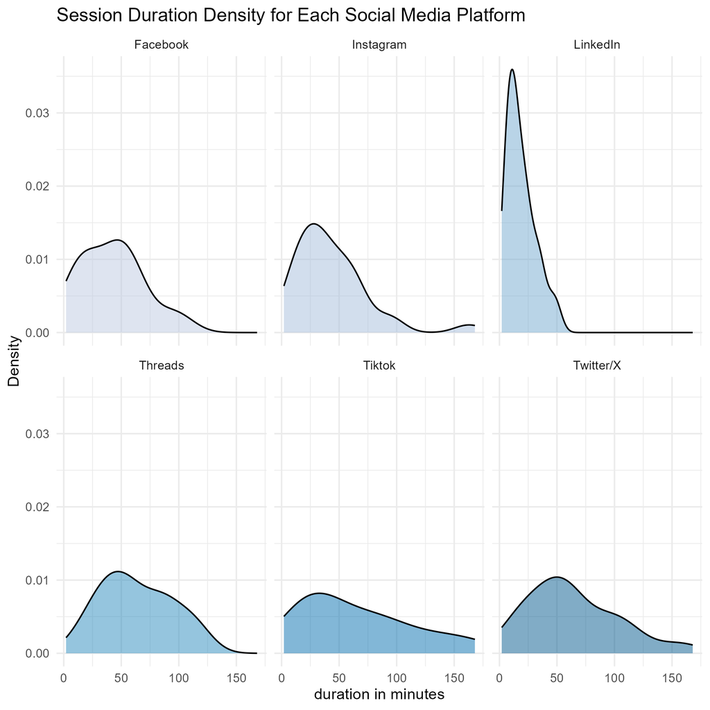

A density graph showing the how much time I spend on social media each session

We can see that Linkedin tends to have shorter sessions of around 15 minutes compare to other social media. The shape of the curve indicate how duration varies where sharper peaks would suggest consistent use and wider spread would suggest variation in duration.

## What device keeps us scrolling longer?

Does the device I use affect how long I stay on social media? This box plot compares session duration by device.

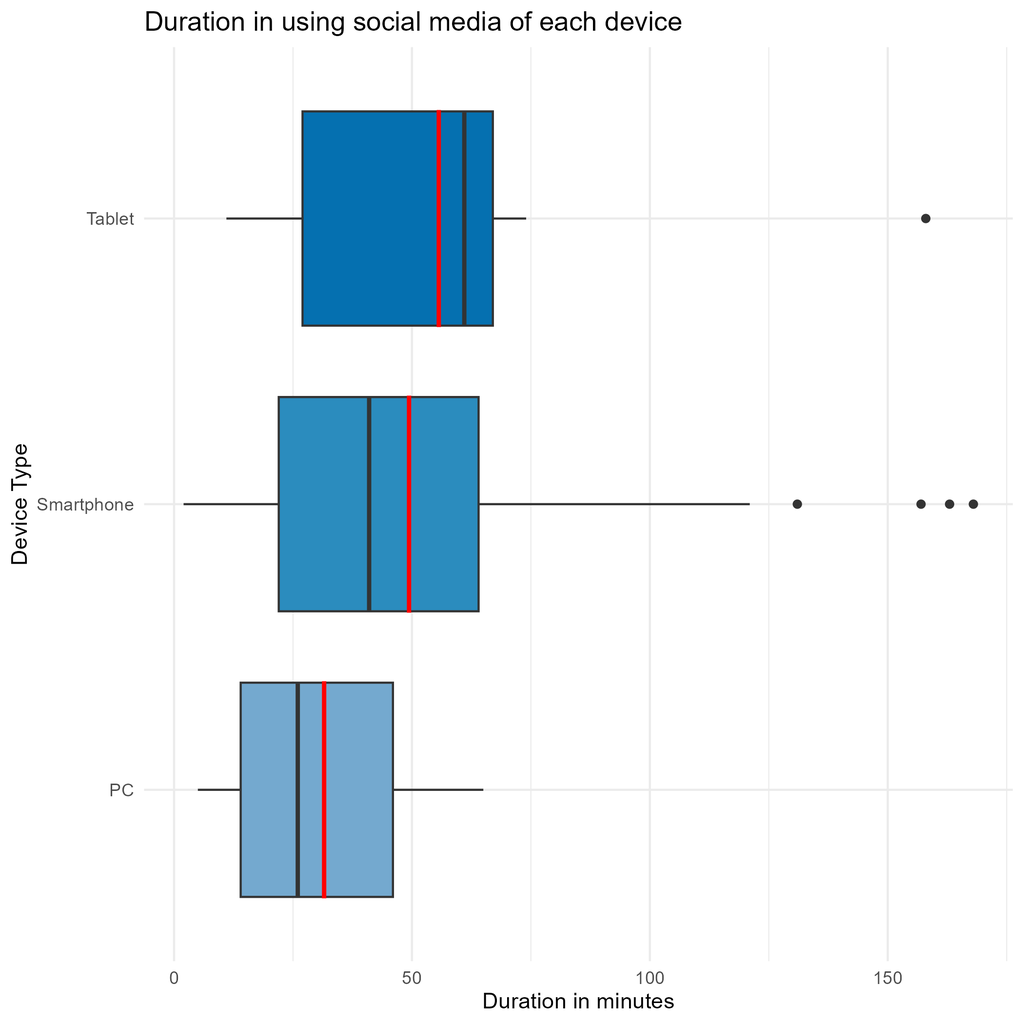

A box plot showing the mean and median of time I spend on social media from each devices

The red line represent mean time and the black line in the box plot represent median time. From both lines we could see that I often spend more time on social media when I’m using my tablet compare to my phone and laptop, which can be due to study breaks when I’m on my tablet.

## What are we doing that takes the most time?

Now moving onto activities that I engage with on social media, does my time spent on social media depends on what activity I’m engaging with?

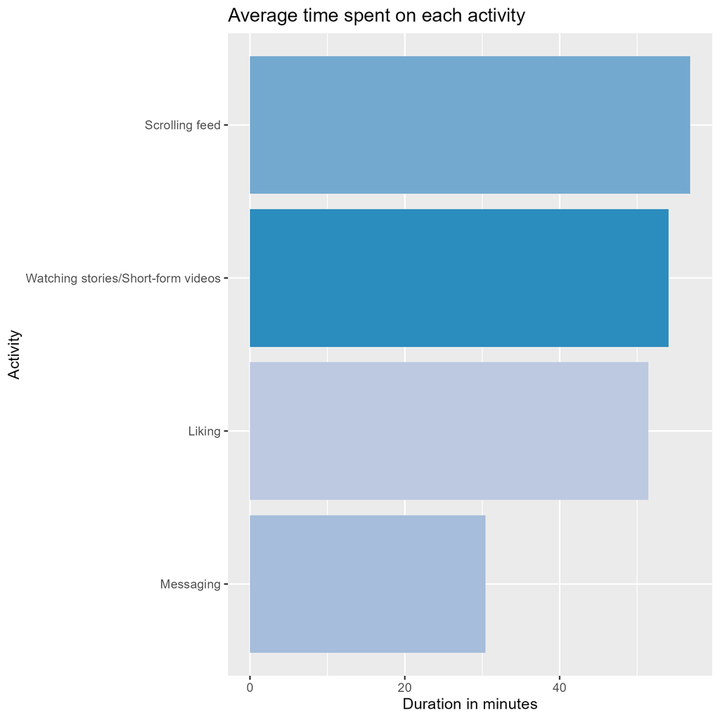

A bar chart showing the average time I spent on social media from each activity

When I’m messaging on social media I spend significantly lesser time compare to other activities.

## Does Time of Day Affect Usage Duration?

Lastly, let’s discover if time of day (AM/PM) affect my time spent on social media

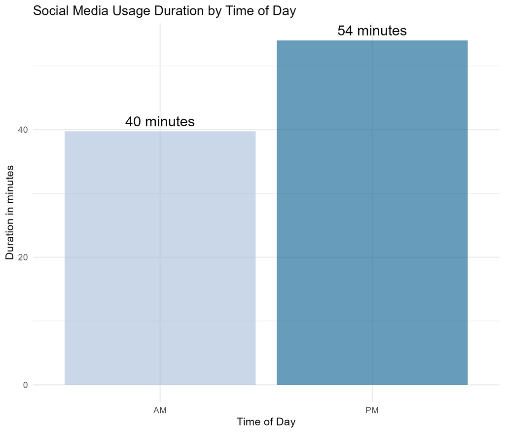

A bar chart showing the average time I spent on social media for AM and PM